# Fatores raciais e prevalência de distocia

# 7 Regressão Múltipla com as variáveis CID 065 e CID068

## 7.1 Regressão Múltipla: variável CID065

```
Criação do modelo e apresentação dos coeficientes.
```

Usaremos o coeficiente Beta para as previsões, segundo Fox (2016)[^1]

```r
mod065 <- lm(corprev_dist$CID_065~ corprev_dist$I1 + corprev_dist$I2 +
               corprev_dist$I3+ corprev_dist$Branca + corprev_dist$Parda + corprev_dist$Preta)

#normalidade mod1
shapiro.test(mod065$residuals)
```

```
##
##  Shapiro-Wilk normality test
##
## data:  mod065$residuals
## W = 0.94822, p-value = 0.462
```

```r
#outliers no resC-duo
summary(rstandard(mod065))
```

```
##    Min. 1st Qu.  Median    Mean 3rd Qu.    Max.
## -2.1247 -0.9089  0.2036 -0.0121  0.6326  2.0070
```

```r
#independencia dos residuos - p < 0,05, DW perto de 2 - n tem residuos correlacionados
lmtest::dwtest(mod065)
```

```
##
##  Durbin-Watson test
##
## data:  mod065
## DW = 1.5161, p-value = 0.02831
## alternative hypothesis: true autocorrelation is greater than 0
```

```r
# Homocedasticidade (Breusch-Pagan): n significativo, p> 0,05 ## tem que existir
lmtest::bptest(mod065)
```

```
##
##  studentized Breusch-Pagan test
##
## data:  mod065
## BP = 6.6985, df = 6, p-value = 0.3496
```

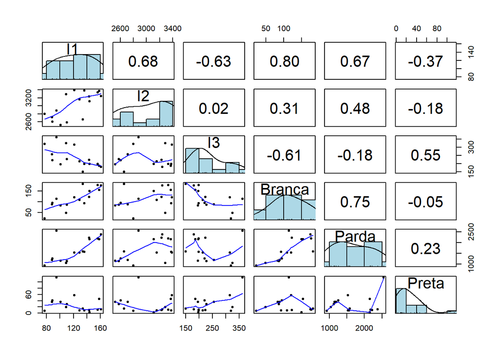

```r
#multicolinearidade - VIF > 10 , R >0,9 OU 0,8 ## n pode existir
library(psych)

# Selecionando as variáveis diretamente do dataframe
selected_vars <- corprev_dist[, c("I1", "I2", "I3", "Branca", "Parda", "Preta")]

pairs.panels(selected_vars,
             method = "pearson",
             hist.col = "lightblue",
             density = TRUE,
             ellipses = FALSE,
             smooth = TRUE)
```

```r
#VIF
library(caTools)
library(car)
vif(mod065)
```

```
##     corprev_dist$I1     corprev_dist$I2     corprev_dist$I3 corprev_dist$Branca
##           22.206000            7.426193            7.363955            6.950804
##  corprev_dist$Parda  corprev_dist$Preta
##            4.495901            2.849640
```

```r
#obtencao dos ceficientes padronizados
lmtest::coefci.default (mod065)
```

```
##                             2.5 %       97.5 %
## (Intercept)           5.722459494 2047.2062234
## corprev_dist$I1     -15.934875777   15.4204114
## corprev_dist$I2      -0.431970094    1.0881718
## corprev_dist$I3      -7.687242137    0.2308022
## corprev_dist$Branca -10.511611869   -0.0581643
## corprev_dist$Parda    0.005536472    0.7243639
## corprev_dist$Preta   -7.109866017    3.7913232
```

```r
summary(mod065)
```

```
##
## Call:
## lm(formula = corprev_dist$CID_065 ~ corprev_dist$I1 + corprev_dist$I2 +
##     corprev_dist$I3 + corprev_dist$Branca + corprev_dist$Parda +
##     corprev_dist$Preta)
##
## Residuals:
##     Min      1Q  Median      3Q     Max
## -226.35 -107.86   26.42   76.91  255.79
##
## Coefficients:
##                      Estimate Std. Error t value Pr(>|t|)
## (Intercept)         1026.4643   451.2250   2.275   0.0490 *
## corprev_dist$I1       -0.2572     6.9304  -0.037   0.9712
## corprev_dist$I2        0.3281     0.3360   0.977   0.3543
## corprev_dist$I3       -3.7282     1.7501  -2.130   0.0620 .
## corprev_dist$Branca   -5.2849     2.3105  -2.287   0.0480 *
## corprev_dist$Parda     0.3650     0.1589   2.297   0.0472 *
## corprev_dist$Preta    -1.6593     2.4095  -0.689   0.5084
## ---
## Signif. codes:  0 '***' 0.001 '**' 0.01 '*' 0.05 '.' 0.1 ' ' 1
##
## Residual standard error: 154.5 on 9 degrees of freedom
## Multiple R-squared:  0.7766, Adjusted R-squared:  0.6277
## F-statistic: 5.215 on 6 and 9 DF,  p-value: 0.01407
```

## 7.2 Regressão Múltipla: variável CID068

```
Criação do modelo e apresentação dos coeficientes
```

```r
mod068 <- lm(corprev_dist$CID_068~ corprev_dist$I1 + corprev_dist$I2 +
               corprev_dist$I3+ corprev_dist$Branca + corprev_dist$Parda + corprev_dist$Preta)

#normalidade mod1
shapiro.test(mod068$residuals)
```

```
##
##  Shapiro-Wilk normality test
##
## data:  mod068$residuals
## W = 0.97194, p-value = 0.869
```

```r
#outliers no resC-duo
summary(rstandard(mod068))
```

```
##     Min.  1st Qu.   Median     Mean  3rd Qu.     Max.
## -1.42614 -0.75634 -0.11315 -0.03686  0.54141  2.11956
```

```r
#independencia dos residuos - p < 0,05, DW perto de 2 - n tem residuos correlacionados
lmtest::dwtest(mod068)
```

```
##
##  Durbin-Watson test
##
## data:  mod068
## DW = 1.558, p-value = 0.03487
## alternative hypothesis: true autocorrelation is greater than 0
```

```r
# Homocedasticidade (Breusch-Pagan): n significativo, p> 0,05 ## tem que existir
lmtest::bptest(mod068)
```

```
##
##  studentized Breusch-Pagan test
##
## data:  mod068
## BP = 6.0099, df = 6, p-value = 0.4221
```

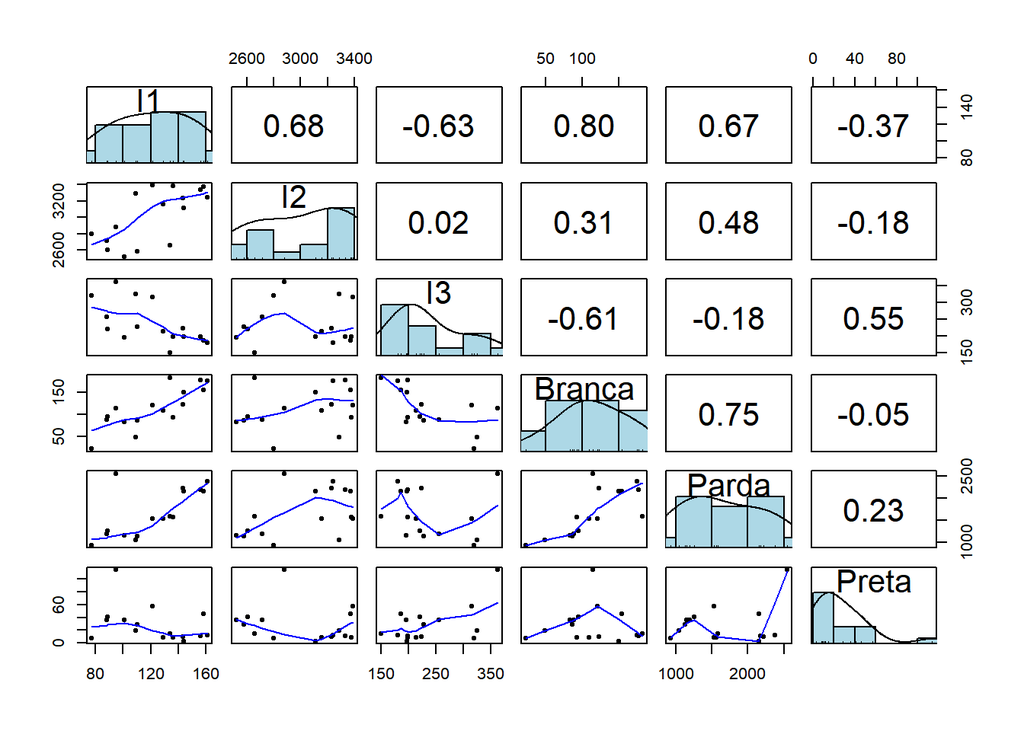

```r
#multicolinearidade - VIF > 10 , R >0,9 OU 0,8 ## n pode existir
library(psych)

# Selecionando as variáveis diretamente do dataframe
selected_vars <- corprev_dist[, c("I1", "I2", "I3", "Branca", "Parda", "Preta")]

pairs.panels(selected_vars,
             method = "pearson",
             hist.col = "lightblue",
             density = TRUE,
             ellipses = FALSE,
             smooth = TRUE)
```

```r
#VIF
library(caTools)
library(car)
vif(mod068)
```

```
##     corprev_dist$I1     corprev_dist$I2     corprev_dist$I3 corprev_dist$Branca
##           22.206000            7.426193            7.363955            6.950804
##  corprev_dist$Parda  corprev_dist$Preta
##            4.495901            2.849640
```

```r
#obtencao dos ceficientes padronizados
lmtest::coefci.default (mod068)
```

```
##                            2.5 %       97.5 %
## (Intercept)         -892.6168914 1569.3904138
## corprev_dist$I1      -16.8024148   21.0117220
## corprev_dist$I2       -0.5812629    1.2520118
## corprev_dist$I3       -5.0397709    4.5093047
## corprev_dist$Branca   -6.7747356    5.8320090
## corprev_dist$Parda    -0.4450965    0.4218016
## corprev_dist$Preta    -4.7344762    8.4122399
```

```r
summary(mod068)
```

```
##
## Call:
## lm(formula = corprev_dist$CID_068 ~ corprev_dist$I1 + corprev_dist$I2 +
##     corprev_dist$I3 + corprev_dist$Branca + corprev_dist$Parda +
##     corprev_dist$Preta)
##
## Residuals:
##     Min      1Q  Median      3Q     Max
## -226.90 -107.19  -14.68   82.65  334.50
##
## Coefficients:
##                      Estimate Std. Error t value Pr(>|t|)
## (Intercept)         338.38676  544.17247   0.622    0.549
## corprev_dist$I1       2.10465    8.35798   0.252    0.807
## corprev_dist$I2       0.33537    0.40520   0.828    0.429
## corprev_dist$I3      -0.26523    2.11061  -0.126    0.903
## corprev_dist$Branca  -0.47136    2.78644  -0.169    0.869
## corprev_dist$Parda   -0.01165    0.19161  -0.061    0.953
## corprev_dist$Preta    1.83888    2.90579   0.633    0.543
##
## Residual standard error: 186.4 on 9 degrees of freedom
## Multiple R-squared:  0.4625, Adjusted R-squared:  0.1042
## F-statistic: 1.291 on 6 and 9 DF,  p-value: 0.3505
```

## 7.3 Referências

[Datadreaming.org](https://www.datadreaming.org/posts/2018-04-11-r-markdown-theme-gallery/2018-04-11-r-markdown-theme-gallery.html)  
[Rviews.rstudio](https://rviews.rstudio.com/2019/01/02/2018-r-views-highlights/)  
[YouTube Fernanda Peres](https://www.youtube.com/watch?v=177TA5Gyse4&t=562s)

```
1. Fox, J. (2016). *Applied regression analysis and generalized linear models* (3rd ed.). Sage.
2. Hosmer, D. W., Lemeshow, S., & Sturdivant, R. X. (2013). *Applied logistic regression* (3rd ed.). Wiley.
3. Gelman, A., & Hill, J. (2006). *Data analysis using regression and multilevel/hierarchical models*. Cambridge University Press.
```

## 7.4 Uso da IA

Os autores agradecem o suporte técnico-científico proporcionado pela plataforma de inteligência artificial DeepSeek Chat (versão DeepSeek-V3) durante as análises deste estudo. A ferramenta foi empregada para:

1 Desenvolvimento e Refinamento Estatístico:

```
    1.1 Implementação e ajuste de modelos de regressão linear múltipla

    1.2 Otimização de parâmetros para modelos não paramétricos (LOESS e GAM)
```

2 Validação Metodológica:

```
    2.1 Padronização dos procedimentos analíticos conforme diretrizes CONSORT/STROBE

    2.2 Verificação de pressupostos estatísticos e diagnóstico de modelos
```

3 Visualização de Dados:

```
    3.1 Geração de visualizações epidemiológicas personalizadas

    3.2 Padronização de gráficos conforme normas de publicação

    3.3 Criação de algoritmos para análise exploratória iterativa
```

Acesso e disponibilidade de dados da DeepSeek [^2]

## 7.5 Notas

[^1]: Fox, J. (2016). *Applied regression analysis and generalized linear models* (3rd ed.). Sage.**p. 80**: “Em modelos de regressão linear múltipla, os coeficientes (β) representam a mudança média na variável dependente contínua para cada aumento unitário no preditor, diferentemente de modelos logísticos, onde razões de chances (OR) são aplicáveis a desfechos binários.” (β) Representa a mudança absoluta na variável dependente para cada aumento unitário no preditor.
[^2]: Assistência técnica em análise de dados realizada via DeepSeek Chat (https://www.deepseek.com) ocorreu entre [02/2025] e [05/2025], utilizando prompts específicos revisados pela equipe de pesquisa.Todos os scripts R desenvolvidos com esta assistência estão disponíveis como material suplementar que pode ser solicitado . Ressalta-se que as interpretações conclusivas e decisões analíticas finais permanecem de exclusiva responsabilidade dos autores.